# Building Models for Stratigraphic Paleobiology in R: Solutions

Author

Niklas Hohmann

This document contains the *solutions* for the tasks of the workshop *Building Models for Stratigraphic Paleobiology in R*. Both code and explanations are given.

## Practical 1: Age-depth models and incompleteness

### Task 1

Question:

1. Define age-depth models for different locations along the onshore-offshore gradient, and plot them.
   - How do they connect to the chronostratigraphic diagram and the sea level curve?

```r
# load packages
library("admtools")
library("StratPal")
# define age-depth models
adm_list = list()                                     # storage for age-depth models
dist = paste(seq(2, 12, by = 2), "km", sep = "")      # distances from shore
for (pos in dist){                                    # construct ADMs for all distances
  adm_list[[pos]] = tp_to_adm(t = scenarioA$t_myr,
                             h = scenarioA$h_m[,pos],
                             T_unit = "Myr",
                             L_unit = "m")
}
```

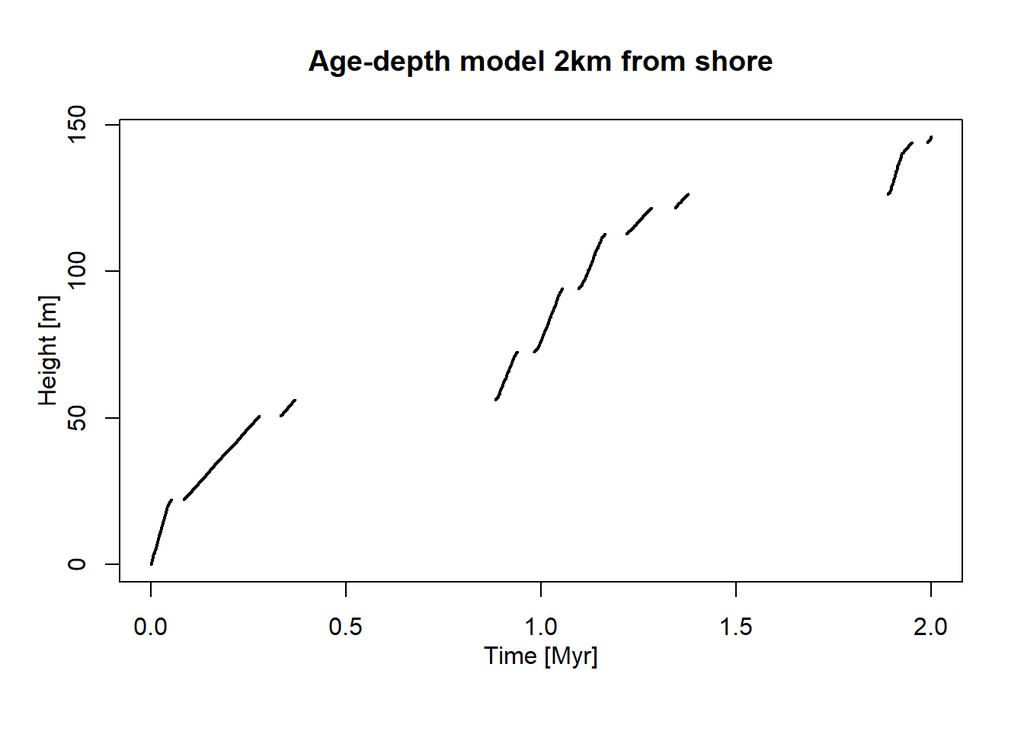

```r
# plot specific age-depth models
pos = "2km"               # insert distance from shore here
stopifnot(pos %in% dist ) # validity check

plot(adm_list[[pos]],
     lwd_acc = 2,         # plot thicker lines for intervals with sediment accumulation (lwd = line width)
     lty_destr = 0)       # don't plot destructive intervals/hiatuses (lty = line type)
T_axis_lab()              # add time axis label
L_axis_lab()              # add length axis label
title(paste0("Age-depth model ", pos, " from shore"))
```

### Task 2

Question:  
2. Examine how stratigraphic incompleteness and the number of hiatuses changes along the onshore-offshore gradient.

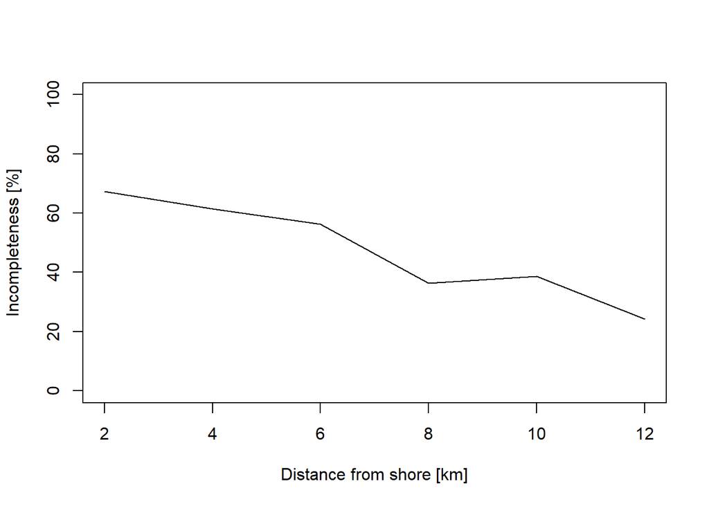

```r
inc = rep(NA, length(dist))             # storage for incompleteness
nhiat = rep(NA, length(dist))           # storage for number of hiatuses
for (i in seq_along(dist)){
  pos = dist[i] # position in platform
  # determine incompleteness
  inc[i] = adm_list[[pos]] |>
    get_incompleteness()
  # determine no. of hiatuses
  nhiat[i] = adm_list[[pos]] |>
    get_hiat_no()
}
## Plotting
p = seq(from = 2, to = 12, by = 2)       # dist from shore for plotting
plot(p, 100 * inc,                       # transform into %
     xlab = "Distance from shore [km]",
     ylab = "Incompleteness [%]",
     type = "l",
     ylim = c(0, 100))
```

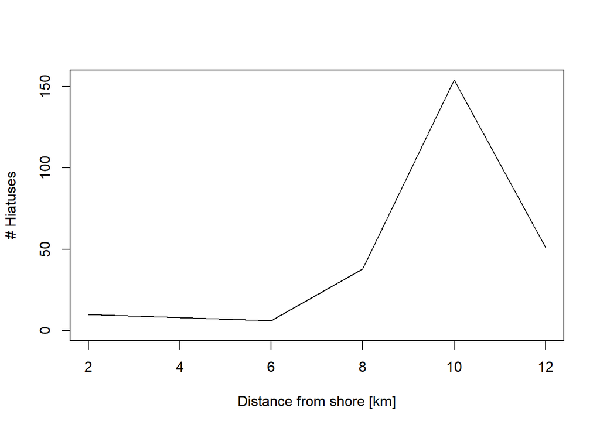

```r
plot(p, nhiat,
     xlab = "Distance from shore [km]",
     ylab = "# Hiatuses",
     type = "l",
     ylim = c(0, max(nhiat)))
```

### Task 3

Questions:

3. Generate histograms of hiatus durations at the different distances from shore.
   - Do you see any systematic changes?

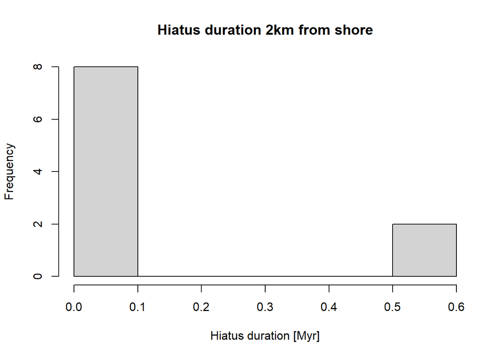

```r
pos = "2km" # position of adm
stopifnot(pos %in%  dist) # validity check

adm_list[[pos]] |>
  get_hiat_duration() |>
  hist(xlab = "Hiatus duration [Myr]",
       main = paste0("Hiatus duration ", pos, " from shore"))
```

Hiatus durations on the platform top are very similar: They consist of two long hiatuses (caused by the prolonged drops in the sea level curve), and a number of shorter hiatuses generated by the lower order sinusoidal sea level changes. At 8 km from shore, the number of short hiatuses increases to more than 30, indicating that sediment accumulation is more interrupted, potentially due to higher wave energy and more sediment transport.  
On the slope, hiatuses are more abundant, but their duration is much shorter. This is most pronounced for the proximal slope.  
Note the disconnect between the number of hiatuses and incompleteness: Onshore sections are the most incomplete, but have only a few hiatuses. In contrast, the proximal slope has the most hiatuses, but a low incompleteness. This is because hiatus duration in the onshore sections is much longer.

## Practical 2: Trait evolution

You can also explore this topic interactively using [DarwinCAT](https://stratigraphicpaleobiology.shinyapps.io/DarwinCAT/).

### Task 1

1. Plot the different modes of evolution in the time domain.
   - What is their internal variation due to randomness (i.e., how much do results differ if you plot them multiple times)?
   - What is the biological meaning of the model parameters?

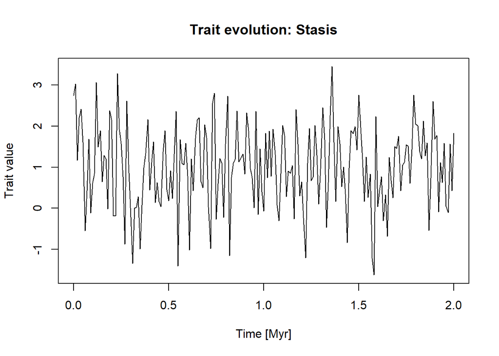

```r
min_t = 0       # beginning observation [Myr]
max_t = 2       # end observation [Myr]
t_step = 0.01   # temporal resolution [Myr]
mean = 1        # model parameter, to modify
sd = 1          # model parameter, to modify
seq(from = min_t, to = max_t, by = t_step) |>
  stasis(mean = mean, sd = sd) |>
  plot(type = "l",
       xlab = "Time [Myr]",
       ylab = "Trait value",
       main = "Trait evolution: Stasis")
```

For stasis, the `mean` parameter determines the mean trait value, and the `sd` (standard deviation) parameter determines the spread of trait values. Trait values at individual times are uncorrelated, so if the temporal resolution is increased, trait evolution appears more irregular.

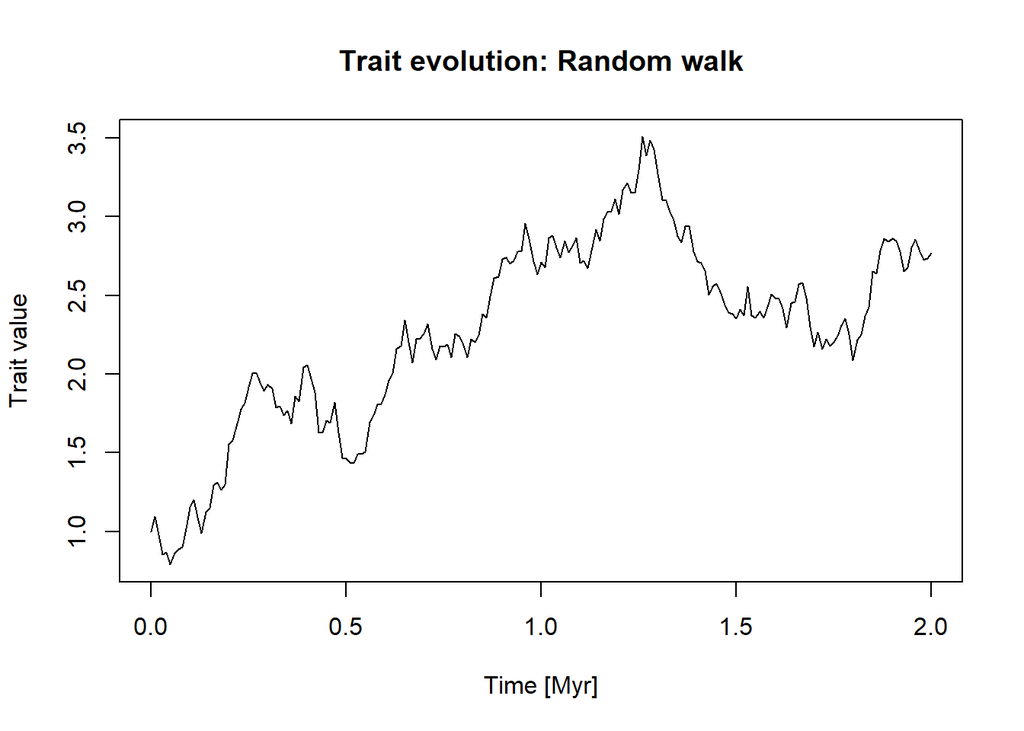

```r
min_t = 0      # beginning observation [Myr]
max_t = 2      # end observation [Myr]
t_step = 0.01  # temporal resolution [Myr]
sigma = 1      # model parameter, to modify
mu = 1         # model parameter, to modify
y0 = 1         # model parameter, to modify
seq(from = min_t, to = max_t, by = t_step) |>
  random_walk(sigma = sigma, mu = mu, y0 = y0) |>
  plot(type = "l",
       xlab = "Time [Myr]",
       ylab = "Trait value",
       main = "Trait evolution: Random walk")
```

For the random walk model, the `y0` parameter determines the initial trait value. The parameter `mu` determines the directionality, with positive (negative) values leading to increasing (decreasing) trait values with time. The `sigma` parameter determines the amount of randomness in the system, with larger values reflecting more randomness. Internal variability is high for larger values of `sigma`, meaning individual lineages simulated will differ a lot from each other.  
Important endmembers are: `sigma` set to 0, trait evolution is purely deterministic and specified by `mu` and `y0`. If `mu` and `y0` are set to 0, trait evolution follows an unbiased random walk model. If `sigma` is set to 1, the model corresponds to a Brownian motion. For low values of `sigma` and `mu`, the random walk can be mistaken for stasis.

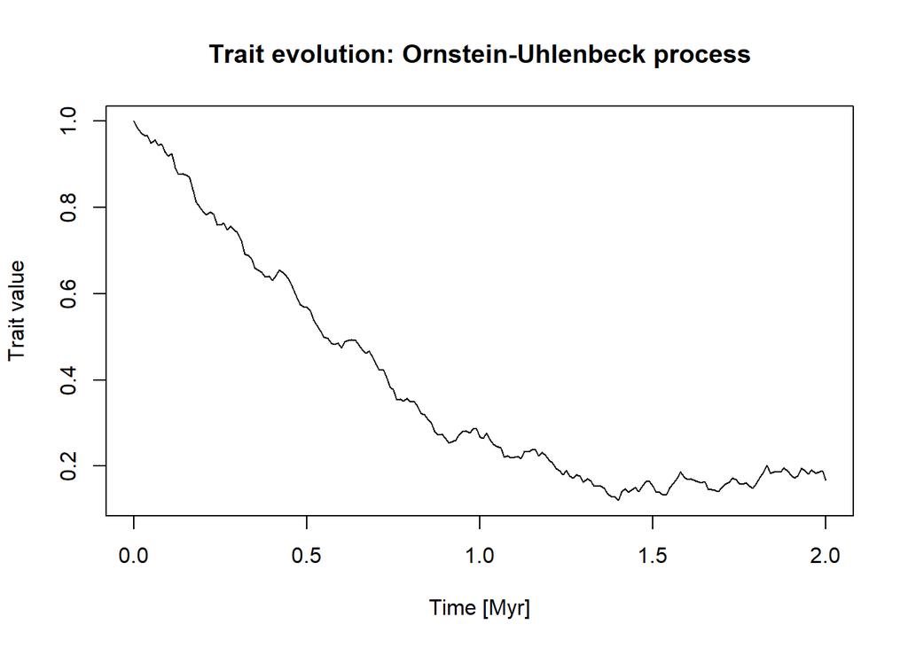

```r
min_t = 0      # beginning observation [Myr]
max_t = 2      # end observation [Myr]
t_step = 0.01  # temporal resolution [Myr]
theta = 1      # model parameter, to modify
sigma = 0.1    # model parameter, to modify
mu = 0         # model parameter, to modify
y0 = 1         # model parameter, to modify
seq(from = min_t, to = max_t, by = t_step) |>
  ornstein_uhlenbeck(mu = mu, theta = theta, sigma = sigma, y0 = y0) |>
  plot(type = "l",
       xlab = "Time [Myr]",
       ylab = "Trait value",
       main = "Trait evolution: Ornstein-Uhlenbeck process")
```

For the Ornstein-Uhlenbeck (OU) model, the parameter `y0` represents the initial trait value. The parameter `mu` determines the long term mean of the process, `theta` how fast this mean is approached, and `sigma` how strong the influence of randomness is. This model is used to model convergence from an initial trait value `y0` to an optimum `mu` under pressure of selection `theta` and random influences `sigma`.  
Internal variation is determined by the `sigma` parameter, where larger values result in greater variation in simulated trait values.  
Important endmembers of the OU model are:

- autocorrelated stasis, when `y0 = mu` (start in the optimum)
- directional evolution when the optimum `mu` is far away from the initial trait value `y0`, and selection is present
- random walk when selection `theta` is 0

### Task 2

2. Transform the different modes of evolution into the stratigraphic domain and plot them.
   - Which modes are most/least affected by stratigraphic biases?
   - Do you see any systematic changes?

Example code for the random walk model is provided. This can be expanded by replacing the random walk by stasis or the Ornstein-Uhlenbeck process.

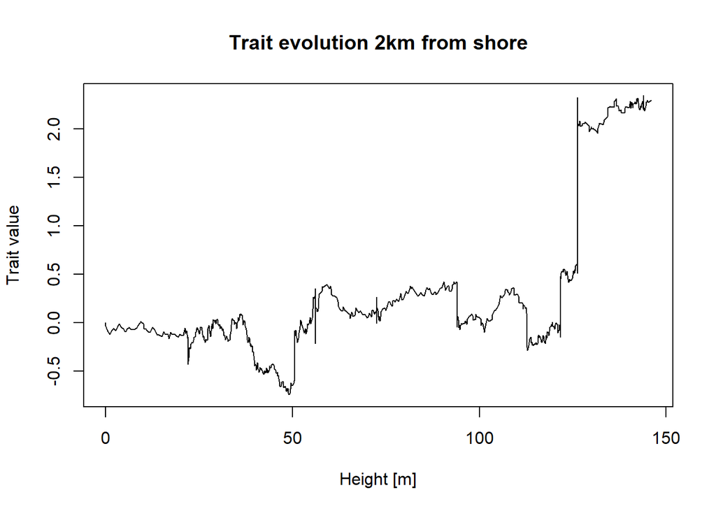

```r
pos = "2km"              # position on platform
stopifnot(pos %in% dist) # validity check
mu = 2                   # model parameters
sigma = 1                # model parameters
y0 = 0                   # model paramters
adm = adm_list[[pos]]    # select age-depth model
t_step = 0.001           # temporal resolution [Myr]
## plot trait evolution in the time domain
seq(from  = min_time(adm), to = max_time(adm), by = t_step) |>
  random_walk(sigma = sigma, mu = mu, y0 = y0) |>
  time_to_strat(adm, destructive = FALSE) |>
  plot(ylab = "Trait value",
       type = "l",
       orientation = "lr",
       xlab = "Height [m]",
       main = paste0("Trait evolution ", pos, " from shore") )
```

Stasis is unaffected by stratigraphic biases. This is because if there is no net change of traits in the time domain, losing parts of the lineage because of hiatuses does not affect the overall pattern.

For the random walk and the Ornstein-Uhlenbeck process, the degree of bias depends on the directionality of evolution. The more the traits change over a hiatus or a condensed interval, the more the stratigraphic expression of trait evolution differs from the one in the time domain. As a result, stratigraphic biases are strongest in the random walk model for large `mu`, and in the Ornstein-Uhlenbeck model for large differences between `y0` and `mu`.

The effects are strongest if

1. There are long hiatuses or
2. There are long intervals of sedimentary condensation.

As a result, stratigraphic biases are driven by maximum hiatus duration on the platform top, and driven by sedimentary condensation on the slope (see task on age-depth models). This effect is more pronounced the more directional evolution is.

## Practical 3: Niche modeling and last occurrences

### Task 1

1. Simulate an abundant taxon, and transform the fossil ages into the stratigraphic domain.
   - At which locations and stratigraphic heights do you observe peaks in fossil abundance?
   - With which stratigraphic effects are these peaks associated?

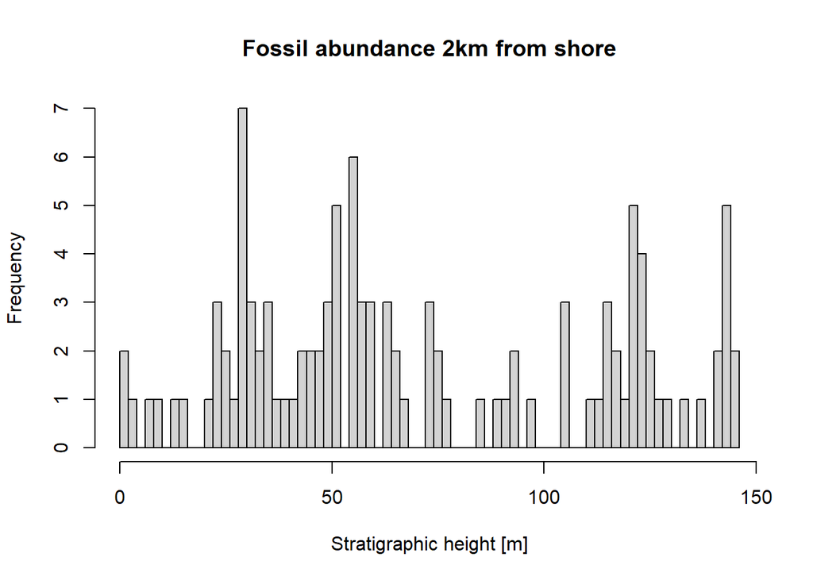

```r
pos = "2km"              # position in the platform, to modify
stopifnot(pos %in% dist) # validity check
adm = adm_list[[pos]]    # select ADM
rate = 200               # fossil occurrences per Myr
sampl_bin = 2            # sampling bins in m
# Plot fossil abundance in the section
p3(from = min_time(adm), to = max_time(adm), rate = rate) |>
  time_to_strat(adm, destructive = TRUE) |>
  hist(breaks = seq(from = min_height(adm), to = max_height(adm) + sampl_bin, by = sampl_bin),
       xlab = "Stratigraphic height [m]",
       main = paste0("Fossil abundance ", pos, " from shore"))
```

In the slope sections (10 and 12 km), there are peaks in fossil abundance associated with the intervals with stratigraphic condensation, which are coeval to drops in sea level. These peaks are not visible on the platform top. This is because here the sea level drops result in hiatuses, which destroys the fossils (as specified by the option `destructive = TRUE`).

### Task 2

2. Define a niche for a taxon, and add the niche model to your pipeline.
   - How and why do your results change?
   - How could you misinterpret the results?

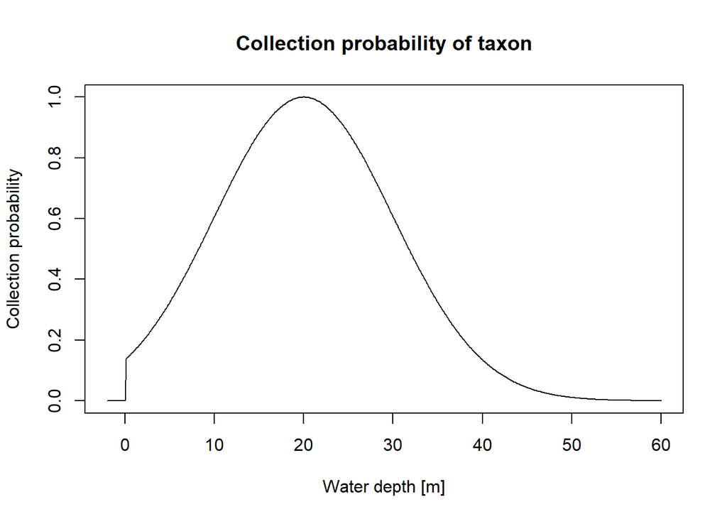

```r
pos = "8km"              # select position on the platform
stopifnot(pos %in% dist) # check validity
adm = adm_list[[pos]]    # select age-depth model
rate = 200               # no. of fossils per Myr
# define niche
niche = snd_niche(opt = 20, tol = 10, cutoff_val = 0)
# plot niche
max_wd = 60                    # maximum water depth for plotting
x = seq(-2, max_wd, by = 0.1)
plot(x, niche(x),
     type = "l",
     xlab = "Water depth [m]",
     ylab = "Collection probability",
     main = "Collection probability of taxon")
```

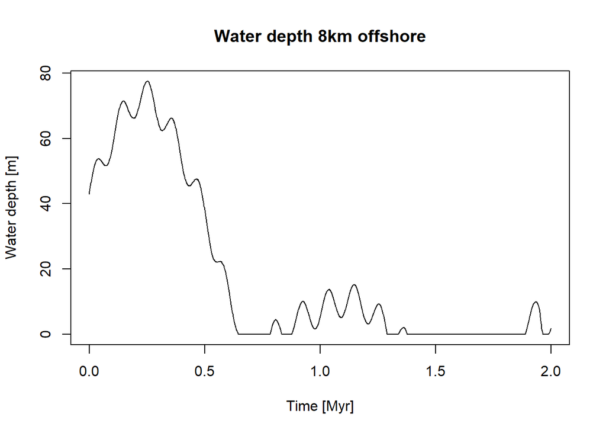

```r
## change in cline with time
t = scenarioA$t_myr        # time steps where the water depth is determined by the model
wd = scenarioA$wd_m[,pos]  # water depth at the specified position
wd_with_time = approxfun(t, wd)
## Plotting
plot(x = t,
     y = wd_with_time(t),
     type = "l",
     xlab = "Time [Myr]",
     ylab = "Water depth [m]",
     main = paste0("Water depth ", pos, " offshore"))
```

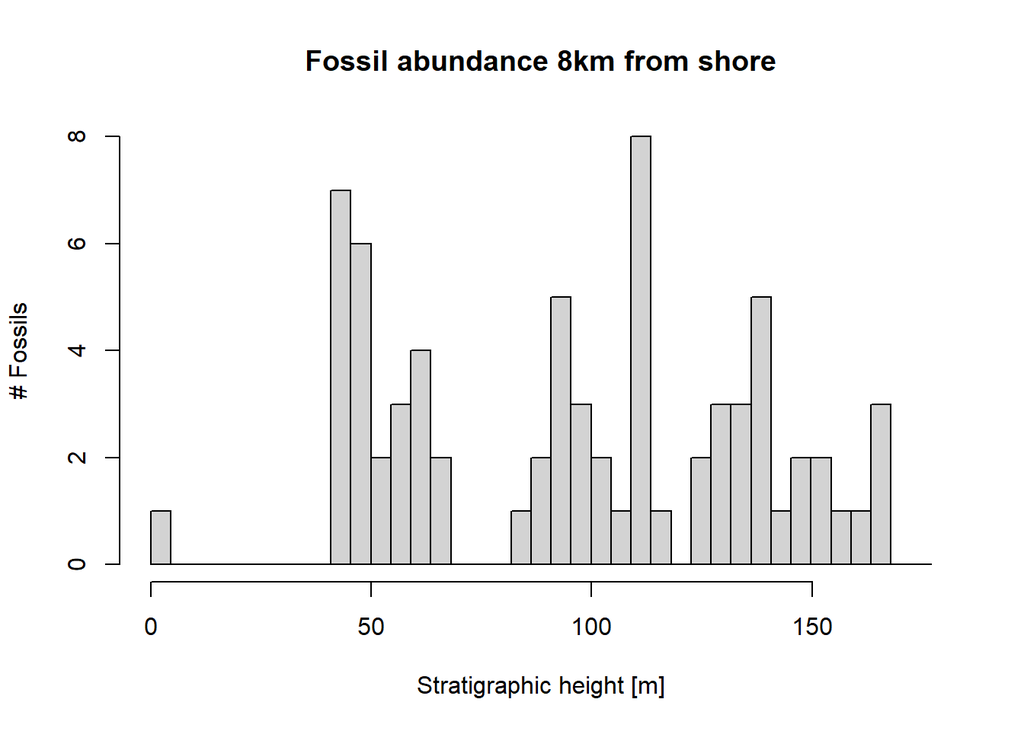

```r
## add niche model to pipeline
p3(rate = rate, from = min_time(adm), to = max_time(adm)) |>         # model occurrences based on constant rate
  apply_niche(niche_def = niche, gc = wd_with_time) |>               # apply niche model
  time_to_strat(adm, destructive = TRUE) |>                          # transform into strat. domain, destroy fossils that coincide with hiatuses
  hist(xlab = paste0("Stratigraphic height [",get_L_unit(adm) ,"]"), # plot results
       main = paste0("Fossil abundance ", pos, " from shore"),
       ylab = "# Fossils",
       breaks = seq(from = min_height(adm), to = max_height(adm), length.out = 40))
```

Depending on the preferred water depth and tolerance to water depth changes, it can appear as if the taxon goes extinct because fossil abundance drops to 0. However, this is because the taxon tracks its niche, and there is a systematic change in water depth with time.  
For example, the water depth on the platform decreases with time, as the carbonate production rate outpaces the subsidence. As a result, taxa with low tolerance to shallow water will vanish over time from the platform top. Conversely, the water depth on the slope increase with time. This leads to the local extinction (extirpation) of shallow water taxa on the slope as time progresses. However, this local extinction does not mean that the taxon is extinct, just that the environment at that location became unfavorable for it. Without the ability to examine multiple sections in the samples, this might be mistaken as a true extinction event.

### Task 3

3. Simulate last occurrences based on the assumption of a constant rate of last occurrences and transform them into the stratigraphic domain.
   - Where do you observe clusters of last occurrences?
   - With what stratigraphic effects are these locations associated?
   - How would you misinterpret the results in the absence of stratigraphic information? Use your results to formulate a “stratigraphic null hypothesis” for clusters of last occurrences.

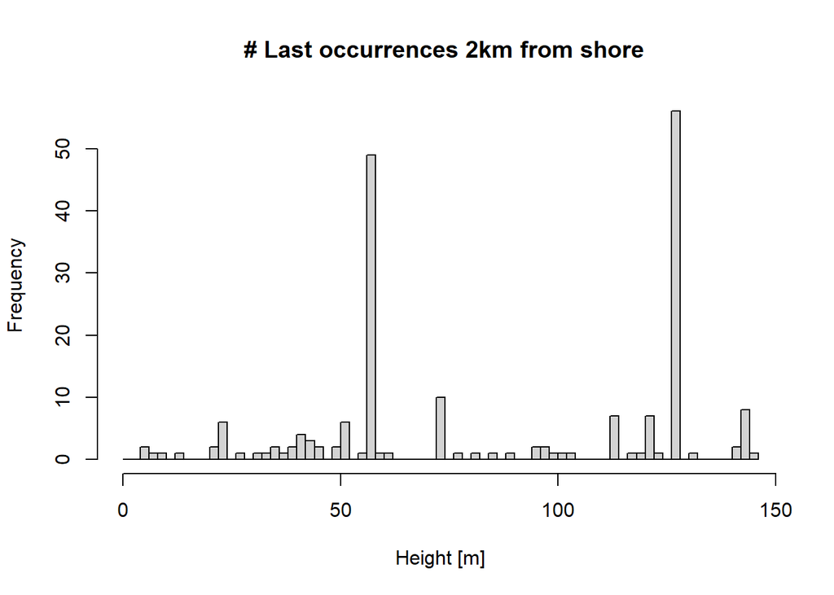

```r
pos = "2km"               # position along the onshore-offshore gradient
stopifnot(pos %in% dist)  # validity check
adm = adm_list[[pos]]     # select age-depth model
rate = 100                # last occurrences per Myr
binsize = 2               # size of sampling bins [m]

# Plot last occurrences at the specified position
p3(from = min_time(adm), to = max_time(adm), rate = rate) |>
  time_to_strat(adm, destructive = FALSE) |>
  hist(breaks = seq(from = min_height(adm), to = max_height(adm) + binsize, by = binsize),
       xlab = "Height [m]",
       main = paste0(" # Last occurrences ", pos, " from shore"))
```

On the platform, the clusters are associated with prolonged hiatuses, caused by drops in sea level. On the slope, the clusters are associated with intervals of stratigraphic condensation (low sedimentation rate), also caused by drops in sea level.  
In the absence of stratigraphic information, these clusters could be misinterpreted as extinction intervals, as there is an elevated rate of last occurrences. If information on sea level change is available, this could be misinterpreted as a causal relationship between sea level and extinction rate, where drops in sea level increase extinction rates.  
A stratigraphic null hypothesis might be that times of dropping sea level cause hiatuses (close to shore) and condensation (on the slope), which lead apparent elevated extinction rates.

## References

Hohmann, Niklas, Joël R. Koelewijn, Peter Burgess, and Emilia Jarochowska. 2024. “Identification of the Mode of Evolution in Incomplete Carbonate Successions.” *BMC Ecology and Evolution* 24 (1): 113. https://doi.org/10.1186/s12862-024-02287-2.